[Link to Github Page](https://blandersonw.github.io)

# CMPS 3160 Final Project - 2012 to 2016 NYSE Analysis

By Blake Anderson and Ethan Sollender

## Collaboration Plan

Our team met every Monday night to discuss review prior work and discuss forward-looking objectives. During this meeting, our team scheduled meeting times for the rest of the week, based on short-term goals. Through meeting on zoom, we were able to write our own code while coordinating different responsibilities--sending code to one another as needed.

## Project Data Set

For this project, we extracted data from a data-bank website (link below).

https://www.kaggle.com/dgawlik/nyse

In order to get this data, we downloaded the .csv file and uploaded it to our github repository. After that, we got the raw data and uploaded it on jupityr to turn it into a dataframe and erased what needed to be erased

## Project Ideas

We are interested in working with this data set because it provides lots of data regarding stock prices and fundamentals, specifically those on the New York Stock Exchange. Unfortunately, many public data sets regarding the stock market only contain data regarding trading metrics, such as stock opening and closing price, volume of stock traded, etc. This data set, however, also provides year ending financial statements such as accounts receivable, accounts payable, profits, capital expenditures, etc.

Given our primary majors, Finance (Blake) and Economics (Ethan), choosing a data set pertaining to company financials is both interesting and applicable to our future careers. With this data, we could perform a number of different operations and analyses in order to achieve some operational insight regarding investment strategies, including but not limited to: momentum/mean-reversion analysis, rolling linear regression, security clustering, and intrinsic valuation vs market valuation.

These strategies could help us analyze questions such as:

-What companies are undervalued relative to past/industry standards?

-To what degree of accuracy can we predict tomorrow’s stock movement (up down and/or price variation)?

-How can we construct a portfolio to limit risk under degree X and ensure returns above Y degree?  
</b>

## Project Goals

How can we predict future share price based on a company's internal financials relative to industry standard?

What level of correlation do changes in fundamentals (internal financials) have on company valuation? Which variables are most highly correlated with changes in share price?

We will answer these questions by comparing changes in individual fundamental variables with subsequent changes in split-adjusted share price. Further, we will also compare valuation with industry standard based on metrics we will develop throughout the project.

## Importing Libraries

```python
#importing everything that will be used
!pip install BeautifulSoup4
!pip install lxml
!pip install mplfinance
import requests
from bs4 import BeautifulSoup
import pandas as pd
import numpy as np
import lxml
import matplotlib.pyplot as plt
import mplfinance as mpf
import math
import random
```

# Data Import and Tidying

Here we downloaded our first dataframe. This data frame includes information regarding internal company financials, market valuation, amongst other information. This will allow us to analyze company valuation based on the financials. As you will see later, we can compare these metrics across industry standards.

```python
fnd = pd.read_csv('https://raw.githubusercontent.com/esollender/esollender.github.io/main/fundamentals.csv')
fnd
```

|  | Unnamed: 0 | Ticker Symbol | Period Ending | Accounts Payable | Accounts Receivable | Add'l income/expense items | After Tax ROE | Capital Expenditures | Capital Surplus | Cash Ratio | ... | Total Current Assets | Total Current Liabilities | Total Equity | Total Liabilities | Total Liabilities & Equity | Total Revenue | Treasury Stock | For Year | Earnings Per Share | Estimated Shares Outstanding |
| --- | --- | --- | --- | --- | --- | --- | --- | --- | --- | --- | --- | --- | --- | --- | --- | --- | --- | --- | --- | --- | --- |
| 0 | 0 | AAL | 2012-12-31 | 3.068000e+09 | -222000000.0 | -1.961000e+09 | 23.0 | -1.888000e+09 | 4.695000e+09 | 53.0 | ... | 7.072000e+09 | 9.011000e+09 | -7.987000e+09 | 2.489100e+10 | 1.690400e+10 | 2.485500e+10 | -367000000.0 | 2012.0 | -5.60 | 3.350000e+08 |
| 1 | 1 | AAL | 2013-12-31 | 4.975000e+09 | -93000000.0 | -2.723000e+09 | 67.0 | -3.114000e+09 | 1.059200e+10 | 75.0 | ... | 1.432300e+10 | 1.380600e+10 | -2.731000e+09 | 4.500900e+10 | 4.227800e+10 | 2.674300e+10 | 0.0 | 2013.0 | -11.25 | 1.630222e+08 |
| 2 | 2 | AAL | 2014-12-31 | 4.668000e+09 | -160000000.0 | -1.500000e+08 | 143.0 | -5.311000e+09 | 1.513500e+10 | 60.0 | ... | 1.175000e+10 | 1.340400e+10 | 2.021000e+09 | 4.120400e+10 | 4.322500e+10 | 4.265000e+10 | 0.0 | 2014.0 | 4.02 | 7.169154e+08 |
| 3 | 3 | AAL | 2015-12-31 | 5.102000e+09 | 352000000.0 | -7.080000e+08 | 135.0 | -6.151000e+09 | 1.159100e+10 | 51.0 | ... | 9.985000e+09 | 1.360500e+10 | 5.635000e+09 | 4.278000e+10 | 4.841500e+10 | 4.099000e+10 | 0.0 | 2015.0 | 11.39 | 6.681299e+08 |
| 4 | 4 | AAP | 2012-12-29 | 2.409453e+09 | -89482000.0 | 6.000000e+05 | 32.0 | -2.711820e+08 | 5.202150e+08 | 23.0 | ... | 3.184200e+09 | 2.559638e+09 | 1.210694e+09 | 3.403120e+09 | 4.613814e+09 | 6.205003e+09 | -27095000.0 | 2012.0 | 5.29 | 7.328355e+07 |
| ... | ... | ... | ... | ... | ... | ... | ... | ... | ... | ... | ... | ... | ... | ... | ... | ... | ... | ... | ... | ... | ... |
| 1776 | 1776 | ZION | 2015-12-31 | 0.000000e+00 | 0.0 | -2.530000e+06 | 4.0 | -1.573610e+08 | 0.000000e+00 | NaN | ... | 0.000000e+00 | 0.000000e+00 | 7.507519e+09 | 5.216201e+10 | 5.966952e+10 | 2.210591e+09 | 0.0 | 2015.0 | 1.20 | 2.578925e+08 |
| 1777 | 1777 | ZTS | 2013-12-31 | 1.381000e+09 | -99000000.0 | 9.000000e+06 | 54.0 | -1.840000e+08 | 8.780000e+08 | 43.0 | ... | 3.357000e+09 | 1.415000e+09 | 9.400000e+08 | 5.618000e+09 | 6.558000e+09 | 4.561000e+09 | 0.0 | 2013.0 | 1.01 | 4.990099e+08 |
| 1778 | 1778 | ZTS | 2014-12-31 | 1.071000e+09 | 69000000.0 | -7.000000e+06 | 44.0 | -1.800000e+08 | 9.580000e+08 | 81.0 | ... | 3.465000e+09 | 1.086000e+09 | 1.311000e+09 | 5.277000e+09 | 6.588000e+09 | 4.785000e+09 | 0.0 | 2014.0 | 1.16 | 5.025862e+08 |
| 1779 | 1779 | ZTS | 2015-12-31 | 1.313000e+09 | -58000000.0 | -8.100000e+07 | 32.0 | -2.240000e+08 | 1.012000e+09 | 65.0 | ... | 3.830000e+09 | 1.781000e+09 | 1.068000e+09 | 6.845000e+09 | 7.913000e+09 | 4.765000e+09 | -203000000.0 | 2015.0 | 0.68 | 4.985294e+08 |
| 1780 | 1780 | ZTS | 2016-12-31 | 1.076000e+09 | 15000000.0 | 2.000000e+06 | 55.0 | -2.160000e+08 | 1.024000e+09 | 65.0 | ... | 3.390000e+09 | 1.117000e+09 | 1.487000e+09 | 6.162000e+09 | 7.649000e+09 | 4.888000e+09 | -421000000.0 | NaN | NaN | NaN |

1781 rows × 79 columns

A company's economic value is heavily contingent on shareholders expecting reimbursement from their investment, which often come in the forms of dividends. On this note, the discounted cash flows method of valuation is extremely common. While it may be difficult to predict stock price using only certain variables, finding variables indicative of future profit growth may prove to also indicate future stock price changes.

Learn more about financial statements: https://www.investopedia.com/terms/f/financial-statements.asp

Learn more about company fair market value: https://online.hbs.edu/blog/post/how-to-value-a-company

In order to create a meaningful analysis, we will begin by removing unncessary columns in each dataframe, beginning with fundamentals ('fnd'), followed by the split adjusted prices (separated by every 2 or 3 years), and finishing with the security information ('sec').

### Fundamentals Spread Sheet - Descriptions for each column are as follows:

1- Ticker Symbol - serves as the identifier for each company.

2- Period Ending - refers to the time frame to which all row info applies.

3- Capital Expenditures - refers to investment. Indicates company's emphasis on investments.

4- Cash and Cash Equivalents - refers to cash holdings. Indicates company's excess free cash to be used for investments and/or daily operations.

5- Cost of Revenue - refers to average company's cost (as a %) to produce/serve their product. Extremely important metric in calculating profit.

6- Depreciation - refers to depreciation on a company's investments. Acts as a contra-asset account.

7- Earnings Before Interest and Tax - otherwise known as EBIT, refers to profit prior to paying interest and tax. Can be used in a variety of valuation equations.

8- Gross Margin - refers to the gross profit (remaining revenue after cost of said revenue) divided by total revenue. Profitability and future growth indicator.

9- Gross Profit - refers to remaining revenue after cost of said revenue.

10- Income Tax - government taxes paid on profit. Usually tax should be a flat rate across all firms, however the complicated U.S. tax system allows some firms to game the system.

11- Intangile Assets - non physical things of value to a firm (i.e. brand). Can be used to less from total assets and determine return on physical assets.

12- Interst Expense - refers to the amount of interest that the firm is paying for their debt.

13- Inventory - refers to product inventory as an asset account. Can be used to measure inventory turnover in relation to sales.

14- Long-Term Debt - refers to long term debt obligations that the firm holds. Can be used in calculating the firm's capital structure which is used in many valuation methods.

15- Long-Term Investment - refers to long term asset holdings. Can be used in calculating the firm's capital structure which is used in many valuation methods.

16- Net Borrowings - refers to the amount of debt borrowed by the firm in the given period.

17- Net Cash Flow - refers to the change in cash during an individual period.

18- Net Cash Flow-Operating - refers to the change in cash during an individual period as a result of operations.

19- Net Cash Flow-Financing - refers to the change in cash during an individual period as a result of financing.

20- Net Cash Flow-Investing - refers to the change in cash during an individual period as a result of investing.

21- Net Income - refers to the after interest, after tax profit of a firm.

22- Operating Income - refers to profit strictly from operations.

23- Operating Margin - ratio of operating income to revenue.

24- Profit Margin - ratio of profit to revenue.

25- Retained Earnings - total profit that company retains (dividends subtract) in the company's entire existence.

26- Sale and Purchase of Stock - buyback / greater issuance of stock.

27- Total Current Assets - total value of assets with high liquidity (<30 days).

28- Total Current Liabilities - total value of debts with immediate payback required (<30 days).

29- Total Equity - total assets less total liabilities. Can be used to indicate shareholders' market value of company's balance sheet.

30- Total Liabilities - total debt owned by the firm. Can be used in a variety of valuation methods, notably in context of firm's capital structure.

31- Total Revenue - total revenue company earns within the given period. Arguably the most important metric.

32- Treasury Stock - internal treasury holdings by the company. Treasury stock consists of stock buybacks and allows for issuance of outstanding shares

33- For Year - the given year in which reporting occurred.

34- Earnings Per Share - the amount of profit earned per company share. Helps estimated future cash flows and one of the most important metrics for determing share price.

35- Estimated Shares Outstanding - the number of shares on the open market. Extremely important number to use in conjunction with the prices dataframe, as multiplying price per share by the estimated shares outstanding allows for market capitalization of the company. Also known as public valuation.

```python
#changing the period ending column into datetime datatype
fnd["Period Ending"] = pd.to_datetime(fnd["Period Ending"], errors= 'coerce')

#Creating a new dataframe and taking the columns from fnd that we need for our analysis
fnd_e1 = fnd[['Ticker Symbol', 'Period Ending', "Capital Expenditures", "Cash and Cash Equivalents", "Cost of Revenue", "Depreciation", "Earnings Before Interest and Tax", "Earnings Before Tax", "Gross Margin", "Gross Profit", "Income Tax", "Intangible Assets", "Interest Expense", "Inventory", "Long-Term Debt", "Long-Term Investments", "Net Borrowings", "Net Cash Flow", "Net Cash Flow-Operating", "Net Cash Flows-Financing", "Net Cash Flows-Investing", "Net Income","Operating Income", "Operating Margin", "Profit Margin", "Retained Earnings", "Sale and Purchase of Stock", "Total Current Assets", "Total Current Liabilities","Total Equity", "Total Liabilities", "Total Revenue", "Treasury Stock", "For Year", "Earnings Per Share", "Estimated Shares Outstanding" ]]
fnd_e1
```

|  | Ticker Symbol | Period Ending | Capital Expenditures | Cash and Cash Equivalents | Cost of Revenue | Depreciation | Earnings Before Interest and Tax | Earnings Before Tax | Gross Margin | Gross Profit | ... | Sale and Purchase of Stock | Total Current Assets | Total Current Liabilities | Total Equity | Total Liabilities | Total Revenue | Treasury Stock | For Year | Earnings Per Share | Estimated Shares Outstanding |
| --- | --- | --- | --- | --- | --- | --- | --- | --- | --- | --- | --- | --- | --- | --- | --- | --- | --- | --- | --- | --- | --- |
| 0 | AAL | 2012-12-31 | -1.888000e+09 | 1.330000e+09 | 1.049900e+10 | 1.001000e+09 | -1.813000e+09 | -2.445000e+09 | 58.0 | 1.435600e+10 | ... | 0.000000e+00 | 7.072000e+09 | 9.011000e+09 | -7.987000e+09 | 2.489100e+10 | 2.485500e+10 | -367000000.0 | 2012.0 | -5.60 | 3.350000e+08 |
| 1 | AAL | 2013-12-31 | -3.114000e+09 | 2.175000e+09 | 1.101900e+10 | 1.020000e+09 | -1.324000e+09 | -2.180000e+09 | 59.0 | 1.572400e+10 | ... | 0.000000e+00 | 1.432300e+10 | 1.380600e+10 | -2.731000e+09 | 4.500900e+10 | 2.674300e+10 | 0.0 | 2013.0 | -11.25 | 1.630222e+08 |
| 2 | AAL | 2014-12-31 | -5.311000e+09 | 1.768000e+09 | 1.562000e+10 | 1.342000e+09 | 4.099000e+09 | 3.212000e+09 | 63.0 | 2.703000e+10 | ... | -1.052000e+09 | 1.175000e+10 | 1.340400e+10 | 2.021000e+09 | 4.120400e+10 | 4.265000e+10 | 0.0 | 2014.0 | 4.02 | 7.169154e+08 |
| 3 | AAL | 2015-12-31 | -6.151000e+09 | 1.085000e+09 | 1.109600e+10 | 1.487000e+09 | 5.496000e+09 | 4.616000e+09 | 73.0 | 2.989400e+10 | ... | -3.846000e+09 | 9.985000e+09 | 1.360500e+10 | 5.635000e+09 | 4.278000e+10 | 4.099000e+10 | 0.0 | 2015.0 | 11.39 | 6.681299e+08 |
| 4 | AAP | 2012-12-29 | -2.711820e+08 | 5.981110e+08 | 3.106967e+09 | 1.895440e+08 | 6.579150e+08 | 6.240740e+08 | 50.0 | 3.098036e+09 | ... | -1.860000e+07 | 3.184200e+09 | 2.559638e+09 | 1.210694e+09 | 3.403120e+09 | 6.205003e+09 | -27095000.0 | 2012.0 | 5.29 | 7.328355e+07 |
| ... | ... | ... | ... | ... | ... | ... | ... | ... | ... | ... | ... | ... | ... | ... | ... | ... | ... | ... | ... | ... | ... |
| 1776 | ZION | 2015-12-31 | -1.573610e+08 | 1.576313e+10 | 4.934400e+07 | 1.510880e+08 | 5.207260e+08 | 4.518590e+08 | 0.0 | 0.000000e+00 | ... | -1.532770e+08 | 0.000000e+00 | 0.000000e+00 | 7.507519e+09 | 5.216201e+10 | 2.210591e+09 | 0.0 | 2015.0 | 1.20 | 2.578925e+08 |
| 1777 | ZTS | 2013-12-31 | -1.840000e+08 | 6.100000e+08 | 1.669000e+09 | 2.090000e+08 | 8.030000e+08 | 6.900000e+08 | 63.0 | 2.892000e+09 | ... | 0.000000e+00 | 3.357000e+09 | 1.415000e+09 | 9.400000e+08 | 5.618000e+09 | 4.561000e+09 | 0.0 | 2013.0 | 1.01 | 4.990099e+08 |
| 1778 | ZTS | 2014-12-31 | -1.800000e+08 | 8.820000e+08 | 1.717000e+09 | 2.040000e+08 | 9.370000e+08 | 8.200000e+08 | 64.0 | 3.068000e+09 | ... | 2.000000e+06 | 3.465000e+09 | 1.086000e+09 | 1.311000e+09 | 5.277000e+09 | 4.785000e+09 | 0.0 | 2014.0 | 1.16 | 5.025862e+08 |
| 1779 | ZTS | 2015-12-31 | -2.240000e+08 | 1.154000e+09 | 1.738000e+09 | 1.990000e+08 | 6.690000e+08 | 5.450000e+08 | 64.0 | 3.027000e+09 | ... | -1.920000e+08 | 3.830000e+09 | 1.781000e+09 | 1.068000e+09 | 6.845000e+09 | 4.765000e+09 | -203000000.0 | 2015.0 | 0.68 | 4.985294e+08 |
| 1780 | ZTS | 2016-12-31 | -2.160000e+08 | 7.270000e+08 | 1.666000e+09 | 2.400000e+08 | 1.394000e+09 | 1.228000e+09 | 66.0 | 3.222000e+09 | ... | -2.750000e+08 | 3.390000e+09 | 1.117000e+09 | 1.487000e+09 | 6.162000e+09 | 4.888000e+09 | -421000000.0 | NaN | NaN | NaN |

1781 rows × 36 columns

# Reading in second set of data

### Prices Spread Sheet - Descriptions for each column are as follows:

1- date - shows the date fpr the following information.

2- symbol - ticker symbol used to identify stocks.

3- open - opening price of the stock on the given trading day.

4- close - closing price of the stock on the given trading day.

5- low - lowest price of the stock on the given trading day.

6- high - highest price of the stock on the given trading day.

7- volume - total volume of the stock bought and sold on the given trading day.

```python
#Data from 2010-2012
prices10to12 = pd.read_csv('https://raw.githubusercontent.com/esollender/esollender.github.io/main/prices-split-adjusted.csv')

#Data from 2013-2014
prices13to14 = pd.read_csv('https://raw.githubusercontent.com/esollender/esollender.github.io/main/prices-split-adjusted2013-2014.csv')

#Data from 2015-2016
prices15to16 = pd.read_csv('https://raw.githubusercontent.com/esollender/esollender.github.io/main/prices-split-adjusted2015-2016.csv')
```

```python
#Dropping unnecessary rows
prices10to12 = prices10to12.drop(columns = ["Unnamed: 7", "Unnamed: 8", "Unnamed: 9"])
prices13to14 = prices13to14.drop(columns = ["Unnamed: 7", "Unnamed: 8", "Unnamed: 9"])
```

```python
#Dropping empty rows in order to tidy up the Dataframe
prices13to14 = prices13to14.drop(labels=range(246104,851264), axis=0)
prices15to16 = prices15to16.drop(labels=range(251082, 851264), axis=0)
```

```python
#Appending the three dataframes together
price_split_e1 = prices10to12.append(prices13to14, ignore_index=True)
price_split = price_split_e1.append(prices15to16, ignore_index=True)

price_split
```

|  | date | symbol | open | close | low | high | volume |
| --- | --- | --- | --- | --- | --- | --- | --- |
| 0 | 1/4/10 | A | 22.453504 | 22.389128 | 22.267525 | 22.625180 | 3815500.0 |
| 1 | 1/4/10 | AAL | 4.840000 | 4.770000 | 4.660000 | 4.940000 | 9837300.0 |
| 2 | 1/4/10 | AAP | 40.700001 | 40.380001 | 40.360001 | 41.040001 | 1701700.0 |
| 3 | 1/4/10 | AAPL | 30.490000 | 30.572857 | 30.340000 | 30.642857 | 123432400.0 |
| 4 | 1/4/10 | ABC | 26.290001 | 26.629999 | 26.139999 | 26.690001 | 2455900.0 |
| ... | ... | ... | ... | ... | ... | ... | ... |
| 851259 | 12/30/16 | ZBH | 103.309998 | 103.199997 | 102.849998 | 103.930000 | 973800.0 |
| 851260 | 12/30/16 | ZION | 43.070000 | 43.040001 | 42.689999 | 43.310001 | 1938100.0 |
| 851261 | 12/30/16 | ZTS | 53.639999 | 53.529999 | 53.270000 | 53.740002 | 1701200.0 |
| 851262 | 12/30/16 | AIV | 44.730000 | 45.450001 | 44.410000 | 45.590000 | 1380900.0 |
| 851263 | 12/30/16 | FTV | 54.200001 | 53.630001 | 53.389999 | 54.480000 | 705100.0 |

851264 rows × 7 columns

Here, below, we download our third data frame. This data frame include stock symbols along with industry information. This will help us in creating models to determine which companies are overvalued by industry standards and which companies are undervalued. We could also use this information to analyze which industries receive the highest vaulations based on internal company financials/health, amongst other things.

```python
sec = pd.read_csv('https://raw.githubusercontent.com/esollender/esollender.github.io/main/securities.csv')
sec
```

|  | Ticker symbol | Security | SEC filings | GICS Sector | GICS Sub Industry | Address of Headquarters | Date first added | CIK |
| --- | --- | --- | --- | --- | --- | --- | --- | --- |
| 0 | MMM | 3M Company | reports | Industrials | Industrial Conglomerates | St. Paul, Minnesota | NaN | 66740 |
| 1 | ABT | Abbott Laboratories | reports | Health Care | Health Care Equipment | North Chicago, Illinois | 1964-03-31 | 1800 |
| 2 | ABBV | AbbVie | reports | Health Care | Pharmaceuticals | North Chicago, Illinois | 2012-12-31 | 1551152 |
| 3 | ACN | Accenture plc | reports | Information Technology | IT Consulting & Other Services | Dublin, Ireland | 2011-07-06 | 1467373 |
| 4 | ATVI | Activision Blizzard | reports | Information Technology | Home Entertainment Software | Santa Monica, California | 2015-08-31 | 718877 |
| ... | ... | ... | ... | ... | ... | ... | ... | ... |
| 500 | YHOO | Yahoo Inc. | reports | Information Technology | Internet Software & Services | Sunnyvale, California | NaN | 1011006 |
| 501 | YUM | Yum! Brands Inc | reports | Consumer Discretionary | Restaurants | Louisville, Kentucky | 1997-10-06 | 1041061 |
| 502 | ZBH | Zimmer Biomet Holdings | reports | Health Care | Health Care Equipment | Warsaw, Indiana | NaN | 1136869 |
| 503 | ZION | Zions Bancorp | reports | Financials | Regional Banks | Salt Lake City, Utah | NaN | 109380 |
| 504 | ZTS | Zoetis | reports | Health Care | Pharmaceuticals | Florham Park, New Jersey | 2013-06-21 | 1555280 |

505 rows × 8 columns

```python
#Checking the datatypes
sec.dtypes
```

```
Ticker symbol              object
Security                   object
SEC filings                object
GICS Sector                object
GICS Sub Industry          object
Address of Headquarters    object
Date first added           object
CIK                         int64
dtype: object
```

```python
#Changing the "Date first added" column to type datetime
sec["Date first added"] = pd.to_datetime(sec["Date first added"])
```

```python
#Replacing all empty entries with NaN
sec.replace("", np.nan)
sec
```

|  | Ticker symbol | Security | SEC filings | GICS Sector | GICS Sub Industry | Address of Headquarters | Date first added | CIK |
| --- | --- | --- | --- | --- | --- | --- | --- | --- |
| 0 | MMM | 3M Company | reports | Industrials | Industrial Conglomerates | St. Paul, Minnesota | NaT | 66740 |
| 1 | ABT | Abbott Laboratories | reports | Health Care | Health Care Equipment | North Chicago, Illinois | 1964-03-31 | 1800 |
| 2 | ABBV | AbbVie | reports | Health Care | Pharmaceuticals | North Chicago, Illinois | 2012-12-31 | 1551152 |
| 3 | ACN | Accenture plc | reports | Information Technology | IT Consulting & Other Services | Dublin, Ireland | 2011-07-06 | 1467373 |
| 4 | ATVI | Activision Blizzard | reports | Information Technology | Home Entertainment Software | Santa Monica, California | 2015-08-31 | 718877 |
| ... | ... | ... | ... | ... | ... | ... | ... | ... |
| 500 | YHOO | Yahoo Inc. | reports | Information Technology | Internet Software & Services | Sunnyvale, California | NaT | 1011006 |
| 501 | YUM | Yum! Brands Inc | reports | Consumer Discretionary | Restaurants | Louisville, Kentucky | 1997-10-06 | 1041061 |
| 502 | ZBH | Zimmer Biomet Holdings | reports | Health Care | Health Care Equipment | Warsaw, Indiana | NaT | 1136869 |
| 503 | ZION | Zions Bancorp | reports | Financials | Regional Banks | Salt Lake City, Utah | NaT | 109380 |
| 504 | ZTS | Zoetis | reports | Health Care | Pharmaceuticals | Florham Park, New Jersey | 2013-06-21 | 1555280 |

505 rows × 8 columns

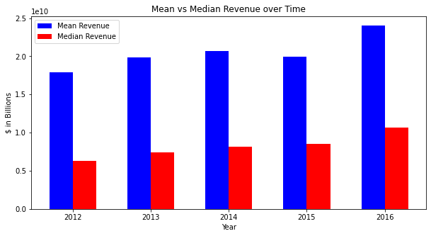

```python
r2012 = []
r2013 = []
r2014 = []
r2015 = []
r2016 = []
for i in range(len(fnd_e1['Period Ending'])):
    if str(fnd_e1['Period Ending'][i])[:4] == '2012':
        r2012.append(fnd_e1['Total Revenue'][i])
    elif str(fnd_e1['Period Ending'][i])[:4] == '2013':
        r2013.append(fnd_e1['Total Revenue'][i])
    elif str(fnd_e1['Period Ending'][i])[:4] == '2014':
        r2014.append(fnd_e1['Total Revenue'][i])
    elif str(fnd_e1['Period Ending'][i])[:4] == '2015':
        r2015.append(fnd_e1['Total Revenue'][i])
    elif str(fnd_e1['Period Ending'][i])[:4] == '2016':
        r2016.append(fnd_e1['Total Revenue'][i])

year_avg = [sum(r2012)/len(r2012), sum(r2013)/len(r2013), sum(r2014)/len(r2014), sum(r2015)/len(r2015), sum(r2016)/len(r2016)]

def median(l):
    a = sorted(l)
    length = (len(a)-1)//2
    if length%2==0:
        return (a[length])
    else:
        return(a[length]/2+a[length+1]/2)
year_med = [median(r2012),median(r2013),median(r2014),median(r2015),median(r2016)]

ind = np.arange(5)
plt.figure(figsize=(10,5))
width = .3

plt.bar(ind, year_avg, width, label="Mean Revenue", color = "blue")
plt.bar(ind+width, year_med, width, label="Median Revenue", color = "red")
plt.title("Mean vs Median Revenue over Time")
plt.xlabel('Year')
plt.ylabel('$ in Billions')
plt.xticks(ind + width/2, ('2012','2013','2014','2015','2016'))
plt.legend(loc = 'best')
plt.show()
```

Here, we plotted mean versus median revenue. This graph shows that revenue is right skewed, meaning that outliers with extraordinarily high revenue skew the mean revenue much higher than the median.

```
236
```

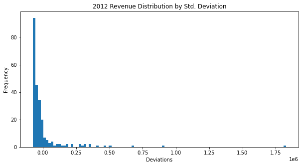

```python
plt.figure(figsize=(10,5))
r2012s = []

s = 0
m = sum(r2012)/len(r2012)
l = len(r2012)
print(l)
for i in r2012:
    q = (int(i)-int(m))**.5
    s+=q
a = s/l

for i in r2012:
    r2012s.append((i-m)/a)

plt.hist(r2012s, density=False, bins=100)
plt.ylabel('Frequency')
plt.xlabel('Deviations')
plt.title("2012 Revenue Distribution by Std. Deviation")
```

Below, we are comparing the Long-Term Debt with the Profit Margins. We decided to normalize the data in order to make the data on a more common scale without changing the ranges of the data or losing information.

```python
#Creating a new Datagrame with just "Long-Term Debt" and "Profit Margin"
profit_and_debt = fnd_e1[["Long-Term Debt", "Profit Margin"]]
```

```python
#Normalizing the data by dividing it by summing the squares and taking the square root.
profit_and_debt_norm = (profit_and_debt / np.sqrt((profit_and_debt **2).sum()))
display(profit_and_debt_norm)
```

|  | Long-Term Debt | Profit Margin |
| --- | --- | --- |
| 0 | 0.005860 | 0.008452 |
| 1 | 0.012642 | 0.007396 |
| 2 | 0.013211 | 0.007396 |
| 3 | 0.015094 | 0.020074 |
| 4 | 0.000498 | 0.006339 |
| ... | ... | ... |
| 1776 | 0.000000 | 0.014792 |
| 1777 | 0.003039 | 0.011622 |
| 1778 | 0.003031 | 0.012679 |
| 1779 | 0.003727 | 0.007396 |
| 1780 | 0.003739 | 0.017961 |

1781 rows × 2 columns

As shown below in this scatter plot, there seems to be little correlation between profit margins and Long-Term Debt with these companies. Companies want to have higher profit markets than long-term debt (which seems to be the case in this scatter plot). However, if a company is capable of paying off their debt in the long run, it is not a major issue

```
(0.0, 0.15)
```

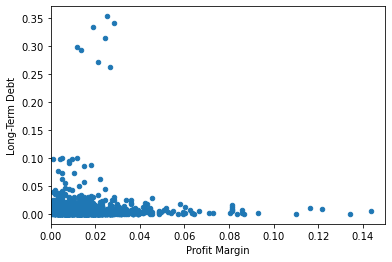

```python
graph1 = profit_and_debt_norm.plot.scatter(x="Profit Margin", y="Long-Term Debt")
graph1.set_xlim([0,.15])
```

To do this, similar to the graph before, we iterated through the "Period Ending" column and the "Total Current Assets" coumn and the "Total Current Liabilities" column. We then took the average of each and plotted it on the same line graph in order to compare the two. We put the lines on the same graph so we could see which ones are greater, where the slopes are similar, and where there are decreases and increases.

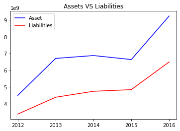

```python
a2012 = []
a2013 = []
a2014 = []
a2015 = []
a2016 = []
l2012 = []
l2013 = []
l2014 = []
l2015 = []
l2016 = []

for i in range(len(fnd_e1['Period Ending'])):
    if str(fnd_e1['Period Ending'][i])[:4] == '2012':
        a2012.append(fnd_e1['Total Current Assets'][i])
    elif str(fnd_e1['Period Ending'][i])[:4] == '2013':
        a2013.append(fnd_e1['Total Current Assets'][i])
    elif str(fnd_e1['Period Ending'][i])[:4] == '2014':
        a2014.append(fnd_e1['Total Current Assets'][i])
    elif str(fnd_e1['Period Ending'][i])[:4] == '2015':
        a2015.append(fnd_e1['Total Current Assets'][i])
    elif str(fnd_e1['Period Ending'][i])[:4] == '2016':
        a2016.append(fnd_e1['Total Current Assets'][i])

for i in range(len(fnd_e1['Period Ending'])):
    if str(fnd_e1['Period Ending'][i])[:4] == '2012':
        l2012.append(fnd_e1['Total Current Liabilities'][i])
    elif str(fnd_e1['Period Ending'][i])[:4] == '2013':
        l2013.append(fnd_e1['Total Current Liabilities'][i])
    elif str(fnd_e1['Period Ending'][i])[:4] == '2014':
        l2014.append(fnd_e1['Total Current Liabilities'][i])
    elif str(fnd_e1['Period Ending'][i])[:4] == '2015':
        l2015.append(fnd_e1['Total Current Liabilities'][i])
    elif str(fnd_e1['Period Ending'][i])[:4] == '2016':
        l2016.append(fnd_e1['Total Current Liabilities'][i])

year_avg_assets = [sum(a2012)/len(a2012), sum(a2013)/len(a2013), sum(a2014)/len(a2014), sum(a2015)/len(a2015), sum(a2016)/len(a2016)]
year_avg_liabilities = [sum(l2012)/len(l2012), sum(l2013)/len(l2013), sum(l2014)/len(l2014), sum(l2015)/len(l2015), sum(l2016)/len(l2016)]

plt.plot(['2012','2013','2014','2015','2016'], year_avg_assets, label="Asset", color = "blue")
plt.plot(['2012','2013','2014','2015','2016'], year_avg_liabilities, label="Liabilities", color = "red")
plt.title("Assets VS Liabilities")
plt.legend()
```

This graph below shows us the price of Apple throughout the years. We will be using graphs like this immensely, as we will plot our valuation methods on the same graph, and hopefully our valuation methods will be an accurate predictor of future price changes. We made this graph by appending all the closing prices in the stock split dataframe that corresponded to the ticker symbol AAPL (Apple). We then appended in the dates and graphed. Unfortunately, the x-axis is cluttered due to the number of dates (thousands). I will work on fixing this titling issues in the coming days.

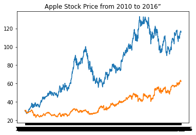

```python
AAPL = []
AAPLdate = []

MSFT = []
MSFTdate = []

for i in range(len(price_split['symbol'])):
    if str(price_split['symbol'][i]) == 'AAPL':
        AAPL.append(price_split['close'][i])
        AAPLdate.append(price_split['date'][i])
for i in range(len(price_split['symbol'])):
    if str(price_split['symbol'][i]) == 'MSFT':
        MSFT.append(price_split['close'][i])
        MSFTdate.append(price_split['date'][i])

plt.plot(AAPLdate, AAPL)
plt.plot(MSFTdate, MSFT)

plt.title("Apple Stock Price from 2010 to 2016”")
```

This graph below shows us the average difference in the spread between the daily high and daily low, divided by the average of the two. Essentially, this tells us the proportion of max change in all stock prices throughout a given day. We could use this to measure the volatility of a stock against the volatility of the NYSE as a whole, known as a company's beta. This is used in many different valuation methods.

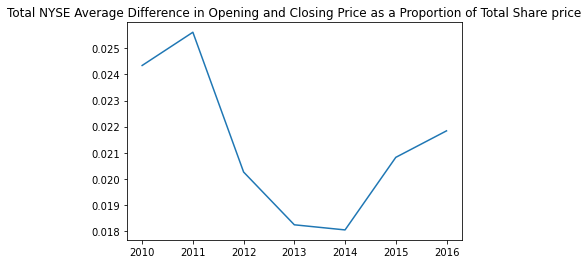

```python
diff2010 = []
diff2011 = []
diff2012 = []
diff2013 = []
diff2014 = []
diff2015 = []
diff2016 = []

for i in range(len(price_split['high'])):
    if str(price_split['date'][i])[-2:] == '10':
        diff2010.append((price_split['high'][i]-price_split['low'][i])/((price_split['high'][i]+price_split['low'][i])/2))
    elif str(price_split['date'][i])[-2:] == '11':
        diff2011.append((price_split['high'][i]-price_split['low'][i])/((price_split['high'][i]+price_split['low'][i])/2))
    elif str(price_split['date'][i])[-2:] == '12':
        diff2012.append((price_split['high'][i]-price_split['low'][i])/((price_split['high'][i]+price_split['low'][i])/2))
    elif str(price_split['date'][i])[-2:] == '13':
        diff2013.append((price_split['high'][i]-price_split['low'][i])/((price_split['high'][i]+price_split['low'][i])/2))
    elif str(price_split['date'][i])[-2:] == '14':
        diff2014.append((price_split['high'][i]-price_split['low'][i])/((price_split['high'][i]+price_split['low'][i])/2))
    elif str(price_split['date'][i])[-2:] == '15':
        diff2015.append((price_split['high'][i]-price_split['low'][i])/((price_split['high'][i]+price_split['low'][i])/2))
    elif str(price_split['date'][i])[-2:] == '16':
        diff2016.append((price_split['high'][i]-price_split['low'][i])/((price_split['high'][i]+price_split['low'][i])/2))

yearavgdiff = [sum(diff2010)/len(diff2010),sum(diff2011)/len(diff2011),sum(diff2012)/len(diff2012),sum(diff2013)/len(diff2013),sum(diff2014)/len(diff2014),sum(diff2015)/len(diff2015),sum(diff2016)/len(diff2016)]

plt.plot(['2010','2011','2012','2013','2014','2015','2016'], yearavgdiff)

plt.title('Total NYSE Average Difference in Opening and Closing Price as a Proportion of Total Share price')
```

## Model Questions

Going forward, we will look to build more intricate models using either those we have already created or the elements and processes of the prior models.

Idea #1

Using the Data frame “sec” and “price_split”, one plausible model we could build is comparing companies within the same Global Industry Classification Standard (GCIS) sector based on its stock price over time (from 2010-2016). Using this data, we could see where some industries are decreasing in value and where are some are increasing in value. We could create a line graph for each industry and track its trend throughout the years. With this information, we could do further research to figure out why certain industries are increasing its valuation while others are not.

The Independent variables would be time and GICS sector and the dependent variable would be the stock price. We would divide each line graph based on GICS sector in order to get a better understanding of each individual sector.

We could use regress analysis in order to predict the dependent variable (stock price) from the independent variables (time and GICS sector)

Idea #2

Using the data frame "fnd" (fundamentals) and "price_split," we can create an equation to value a company. For example, a basic valuation method could be 80% times total equity, also known as book value plus 1 divided by the required growth rate multiplied by the net income (.8*E+(1/g)*NI). We could use this equation to calculate a fair per share value of the stock. After calculating the fair per share value, we could plot the graph for each company each year, and compare the fair valuation based on our equation to the market valuation. Then, we could calculate the variance for each stock and measure across industries.

Which industries does the market value much higher than our equation? Which industries does the market value less?

After this analysis, we can optimize equations on a per industry basis. The independent variable graphed would be time, but also all of the internal company financials used to create the valuation metric. The dependent variables would be actual share price, actual market cap, predicted share price, and predicted market cap.

We could use a number of different regression analyses and statistical methods to further interpret these results. One that we are particularly interested in is LASSO.

```python
#Sorting the price_split DataFrame by symbol and then sorting it by date for each symbol.
#We are then making the Symbol the index.

price_split['date']= pd.to_datetime(price_split['date'])
price_split = price_split.sort_values(["symbol","date"])
price_split = price_split.set_index('symbol')
```

```python
#Getting information only from Apple
Apple = price_split.loc["AAPL"]
```

```python
#Setting the index to the date so we can graph it
stock_price_date = Apple.set_index("date")
stock_price = stock_price_date.iloc[0:90]
```

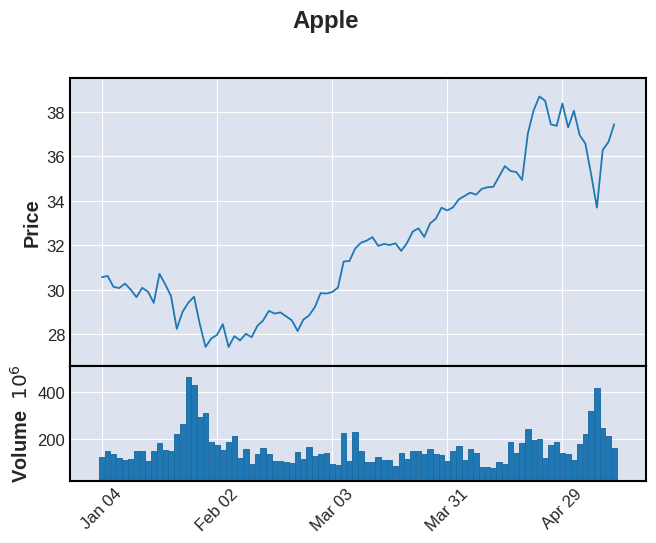

```python
#Plotting stock price of Apple
mpf.plot(stock_price, type='line', volume=True, title="Apple")
```

The MACD is stands for "Moving Average Convergence Divergence". It is a form of a means-reverseions strategy, which is a model that follows the momentum of trends by showing the relationship between two moving averages of the price of a stock. In simple terms, it is calculated by the difference between two different days individual exponential moving averages.

```python
#https://github.com/matplotlib/mplfinance/blob/master/examples/addplot.ipynb

#Here we are calculating the MACD. The MACD is calculating by taking
#the difference in the exponential weighted means of two different days.
exp12 = stock_price['close'].ewm(span=12, adjust=False).mean()
exp26 = stock_price['close'].ewm(span=26, adjust=False).mean()

macd = exp12 - exp26
signal = macd.ewm(span=9, adjust=False).mean()
histogram = macd - signal

apds = [
        mpf.make_addplot(histogram,type='bar',width=0.7,panel=1,
                         color='dimgray',alpha=1,secondary_y=False),
        mpf.make_addplot(macd,panel=1,color='fuchsia',secondary_y=True),
        mpf.make_addplot(signal,panel=1,color='b',secondary_y=True),
       ]
```

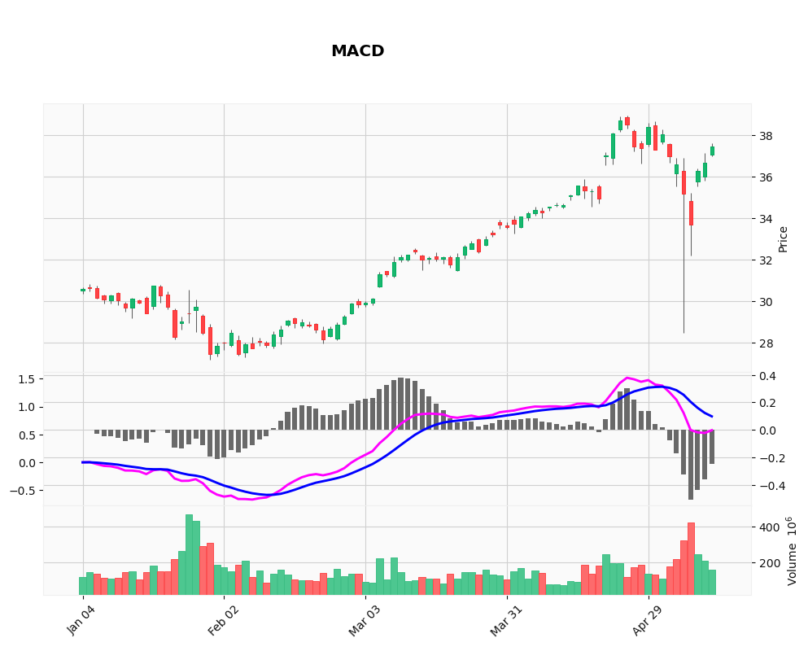

```python
#Here we are implementing the MACD into the graph above by using the MACD, signal, and histogram

yahoo = mpf.make_mpf_style(base_mpf_style='yahoo')

mpf.plot(stock_price,type='candle',addplot=apds,figscale=1.5,figratio=(7,5),title='\n\nMACD',
                     style=yahoo,volume=True,volume_panel=2,panel_ratios=(6,3,2),returnfig=False)
stock_price['macd'] = stock_price.index.map(macd)
stock_price['macd_s'] = stock_price.index.map(signal)
stock_price['macd_h'] = stock_price.index.map(histogram)
```

```python
#Here, we are displaying the the exact data points of the MACD, the signal, and the histogram.
apple_macd = stock_price[["macd", "macd_s", "macd_h"]]
apple_macd
```

| date | macd | macd_s | macd_h |
| --- | --- | --- | --- |
| 2010-01-04 | 0.000000 | 0.000000 | 0.000000 |
| 2010-01-05 | 0.004216 | 0.000843 | 0.003373 |
| 2010-01-06 | -0.031388 | -0.005603 | -0.025785 |
| 2010-01-07 | -0.063371 | -0.017157 | -0.046214 |
| 2010-01-08 | -0.071751 | -0.028076 | -0.043676 |
| ... | ... | ... | ... |
| 2010-05-06 | 0.889754 | 1.212422 | -0.322668 |
| 2010-05-07 | 0.580054 | 1.085948 | -0.505894 |
| 2010-05-10 | 0.537411 | 0.976241 | -0.438829 |
| 2010-05-11 | 0.526709 | 0.886335 | -0.359625 |
| 2010-05-12 | 0.575798 | 0.824227 | -0.248429 |

90 rows × 3 columns

```python
#Here are we calculating the buy price and sell price. This is calculated when the MACD line crosses the signal line.

def implement_macd_strategy(prices, data):
    buy_price = []
    sell_price = []
    macd_signal = []
    signal = 0

    for i in range(len(data)):
        if data['macd'][i] > data['macd_s'][i]:
            if signal != 1:
                buy_price.append(prices[i])
                sell_price.append(np.nan)
                signal = 1
                macd_signal.append(signal)
            else:
                buy_price.append(np.nan)
                sell_price.append(np.nan)
                macd_signal.append(0)
        elif data['macd'][i] < data['macd_s'][i]:
            if signal != -1:
                buy_price.append(np.nan)
                sell_price.append(prices[i])
                signal = -1
                macd_signal.append(signal)
            else:
                buy_price.append(np.nan)
                sell_price.append(np.nan)
                macd_signal.append(0)
        else:
            buy_price.append(np.nan)
            sell_price.append(np.nan)
            macd_signal.append(0)

    return buy_price, sell_price, macd_signal

buy_price, sell_price, macd_signal = implement_macd_strategy(stock_price['close'], apple_macd)
```

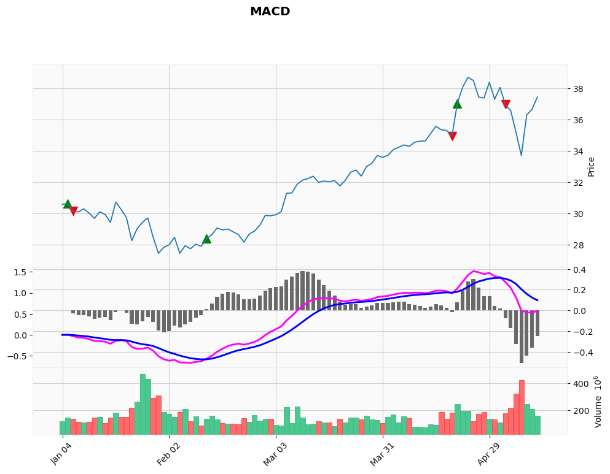

```python
#https://github.com/matplotlib/mplfinance/blob/master/examples/addplot.ipynb

#Here we are adding in the red and green triangles as visuals. This displays where one should sell or buy, according
#to the MACD method.

apds = [
        mpf.make_addplot(buy_price, type='scatter', marker = '^', color = 'green', markersize = 100),
        mpf.make_addplot(sell_price, type='scatter', marker = 'v', color = 'r', markersize = 100),
        mpf.make_addplot(histogram,type='bar',width=0.7,panel=1, color='dimgray',alpha=1,secondary_y=False),
        mpf.make_addplot(macd,panel=1,color='fuchsia',secondary_y=True),
        mpf.make_addplot(signal,panel=1,color='b',secondary_y=True),
       ]

yahoo = mpf.make_mpf_style(base_mpf_style='yahoo')

fig, axis = mpf.plot(stock_price,type='line',addplot=apds,figscale=1.5,figratio=(7,5),title='MACD',
                     style=yahoo,volume=True,volume_panel=2,panel_ratios=(6,3,2),returnfig=True)
```

```python
#implementing the calculate running profit function as a test run

running_profit = 0
curr_pos = 0
curr_buy = 0
curr_sell = 0


for b_price, s_price, macd_s in zip(buy_price, sell_price, macd_signal):

    if macd_s != 0:
        if macd_s == -1:

            if curr_pos == 1:
                running_profit += s_price - curr_buy
                curr_sell = s_price
                curr_buy = 0
                curr_pos = -1

            if curr_pos == 0:
                curr_sell = s_price
                curr_pos = -1

        if macd_s == 1:

            if curr_pos == -1:
                running_profit += curr_sell - b_price
                curr_sell = 0
                curr_buy = b_price
                curr_pos = 1
            if curr_pos == 0:
                curr_buy = b_price
                curr_pos = 1

if curr_pos == -1 or 1:
    if curr_pos == 1:
        running_profit += stock_price["close"][-1] - curr_buy
        curr_pos = 0
        curr_sell = 0
        curr_buy = 0
    if curr_pos == -1:
        running_profit += curr_sell - stock_price["close"][-1]
```

```python
#https://medium.com/codex/algorithmic-trading-with-macd-in-python-1c2769a6ad1b

#Creating a Class "Stock" so we can create these graphs for anything we want. We also created objects for each year.

class Stock(object):
    def __init__(self, ticker, DataFrame):
        self.DataFrame = DataFrame
        self.DataFrame = self.DataFrame.set_index("date")
        self.ticker = ticker
        self.year_2010 = self.DataFrame.iloc[0:242]
        self.year_2011 = self.DataFrame.iloc[243:480]
        self.year_2012 = self.DataFrame.iloc[482:780]
        self.year_2013 = self.DataFrame.iloc[781:1120]
        self.year_2014 = self.DataFrame.iloc[1121:1361]
        self.year_2015 = self.DataFrame.iloc[1361:1599]
        self.year_2016 = self.DataFrame.iloc[1600:1841]
        self.year2010to2016 = self.DataFrame.iloc[0:1841]


    #function to create the MACD line (blue line)
    def create_macd(self, data):
        exp12 = data['close'].ewm(span=12, adjust=False).mean()
        exp26 = data['close'].ewm(span=26, adjust=False).mean()

        macd = exp12 - exp26
        signal = macd.ewm(span=9, adjust=False).mean()
        histogram = macd - signal

        data['macd'] = data.index.map(macd)
        data['macd_s'] = data.index.map(signal)
        data['macd_h'] = data.index.map(histogram)
        full_macd = data[["macd", "macd_s", "macd_h"]]

        buy_price, sell_price, macd_signal = self.implement_macd_strategy(data['close'], full_macd)
        apds = [
            mpf.make_addplot(buy_price, type='scatter', marker = '^', color = 'green', markersize = 100),
            mpf.make_addplot(sell_price, type='scatter', marker = 'v', color = 'r', markersize = 100),
            mpf.make_addplot(histogram,type='bar',width=0.7,panel=1, color='dimgray',alpha=1,secondary_y=False),
            mpf.make_addplot(macd,panel=1,color='fuchsia',secondary_y=True),
            mpf.make_addplot(signal,panel=1,color='b',secondary_y=True),
           ]

        yahoo = mpf.make_mpf_style(base_mpf_style='yahoo')
        mpf.plot(data, type='line',addplot=apds,figscale=1.5,figratio=(7,5),title='\n\nMACD',
                         style=yahoo,volume=True,volume_panel=2,panel_ratios=(6,3,2),returnfig=False)

        profit = self.calc_running_proft(data, buy_price, sell_price, macd_signal)
        print(profit)

    def implement_macd_strategy(self, prices, data):
        buy_price = []
        sell_price = []
        macd_signal = []
        signal = 0

        for i in range(len(data)):
            if data['macd'][i] > data['macd_s'][i]:
                if signal != 1:
                    buy_price.append(prices[i])
                    sell_price.append(np.nan)
                    signal = 1
                    macd_signal.append(signal)
                else:
                    buy_price.append(np.nan)
                    sell_price.append(np.nan)
                    macd_signal.append(0)
            elif data['macd'][i] < data['macd_s'][i]:
                if signal != -1:
                    buy_price.append(np.nan)
                    sell_price.append(prices[i])
                    signal = -1
                    macd_signal.append(signal)
                else:
                    buy_price.append(np.nan)
                    sell_price.append(np.nan)
                    macd_signal.append(0)
            else:
                buy_price.append(np.nan)
                sell_price.append(np.nan)
                macd_signal.append(0)

        return buy_price, sell_price, macd_signal

    #Function to calculate total earnings. We will start with a balance of $100 and invest that to see what our
    #profit will be.
    def calc_running_proft(self, data, buy_price, sell_price, macd_signal):
        starting_balance = 100
        curr_pos = 0
        curr_buy = 0
        curr_sell = 0

        for b_price, s_price, macd_s in zip(buy_price, sell_price, macd_signal):
            if macd_s != 0:
                if macd_s == -1:
                    if curr_pos == 1:
                        starting_balance += (s_price - curr_buy)
                        curr_sell = s_price
                        curr_buy = 0
                        curr_pos = -1
                    if curr_pos == 0:
                        curr_sell = s_price
                        curr_pos = -1

                if macd_s == 1:
                    if curr_pos == -1:
                        starting_balance += (curr_sell - b_price)
                        curr_sell = 0
                        curr_buy = b_price
                        curr_pos = 1
                if curr_pos == 0:
                    curr_buy = b_price
                    curr_pos = 1
        if curr_pos == -1 or 1:
            if curr_pos == 1:
                starting_balance += (data["close"][-1] - curr_buy)
                curr_pos = 0
                curr_sell = 0
                curr_buy = 0
            if curr_pos == -1:
                starting_balance += curr_sell - data["close"][-1]

        return starting_balance
```

```python
#Creating the Apple Object
apple_stock = price_split.loc["AAPL"]
apple_object = Stock("AAPL", apple_stock)
```

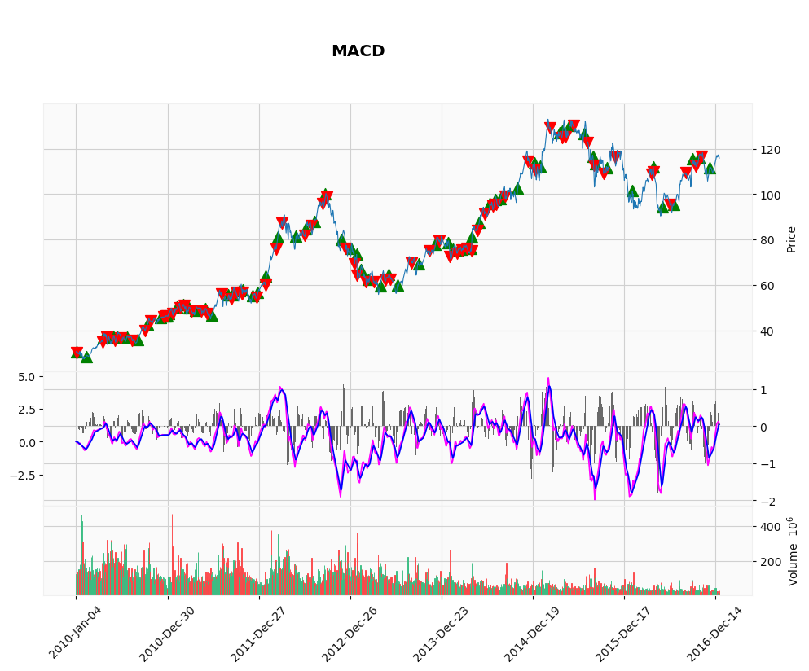

```
130.02856125000002
```

```python
#Creating the MACD visual with our Apple object.
apple_object.create_macd(apple_object.year2010to2016)
```

Here we have our MACD model of Apple from the beginning of 2010 to the end of 2016. Although it seems a little crowded, you can see the trend of the stock price of Apple from 2010 to the end of 2016. As explained before, the green triangles represent when our model says to make a purchase call and the red triangles represent when our model says to make a sell call.

In 2010, the price of apple was hovering around 30 dollars. Towards the end of 2016, it was almost 120 dollars. If someone had one share of Apple for this time period, they would have made almost $90, a 300% increase of their investment.

However, our model did not do as well. The number shown below the graph represents the running profit. We started with 100 dollars and finished with 130 dollars. From 2010 to 2016, we brought in 30 dollars, a 30% increase of their investment.

Our goal was to come up with a way to get abnormal returns for Apple. As you can see, our MACD reversions strategy model did not beat the normal returns of Apple. The stock market is extremely complex and most algorithms created to this day still fail to beat the market. According to Investopedia.com, it is very difficult for day traders to consistently beat the market. When you factor in investment fees, taxes, and human emotion, luck usually works better than skill.

## Intrinsic Valuation Method

Began by creating a new dataframe with necessary metrics of valuation (ticker symbol, earnings per share, and shares outstanding).

```python
fnd_e1.head()
valuationdf = fnd_e1[['Ticker Symbol', 'Period Ending','Total Equity', 'Earnings Per Share', 'Estimated Shares Outstanding']]
valuationdf['Equity Per Share'] = valuationdf['Total Equity']/valuationdf['Estimated Shares Outstanding']

valuationdf['Share Value'] = (valuationdf['Earnings Per Share']*20 + valuationdf['Equity Per Share'])
valuationdf.head()
```

|  | Ticker Symbol | Period Ending | Total Equity | Earnings Per Share | Estimated Shares Outstanding | Equity Per Share | Share Value |
| --- | --- | --- | --- | --- | --- | --- | --- |
| 0 | AAL | 2012-12-31 | -7.987000e+09 | -5.60 | 3.350000e+08 | -23.841791 | -135.841791 |
| 1 | AAL | 2013-12-31 | -2.731000e+09 | -11.25 | 1.630222e+08 | -16.752317 | -241.752317 |
| 2 | AAL | 2014-12-31 | 2.021000e+09 | 4.02 | 7.169154e+08 | 2.819022 | 83.219022 |
| 3 | AAL | 2015-12-31 | 5.635000e+09 | 11.39 | 6.681299e+08 | 8.433988 | 236.233988 |
| 4 | AAP | 2012-12-29 | 1.210694e+09 | 5.29 | 7.328355e+07 | 16.520678 | 122.320678 |

We then merged our valuation dataframe with the price-split-adjusted dataframe to create one dataframe containing our calculated fair share price compared against the actual stock price at the end of each year.

```python
price_split['date']= pd.to_datetime(price_split['date'])
price_split['Period Ending'] = price_split['date']
price_split['Stock Price'] = price_split['close']
price_split['Ticker Symbol'] = price_split.index
pricevaldf = price_split[['Period Ending','Stock Price','Ticker Symbol']]
mrgval = pd.merge(valuationdf, pricevaldf, on = ['Period Ending','Ticker Symbol'])
mrgval.head()
```

|  | Ticker Symbol | Period Ending | Total Equity | Earnings Per Share | Estimated Shares Outstanding | Equity Per Share | Share Value | Stock Price |
| --- | --- | --- | --- | --- | --- | --- | --- | --- |
| 0 | AAL | 2012-12-31 | -7.987000e+09 | -5.60 | 3.350000e+08 | -23.841791 | -135.841791 | 13.500000 |
| 1 | AAL | 2013-12-31 | -2.731000e+09 | -11.25 | 1.630222e+08 | -16.752317 | -241.752317 | 25.250000 |
| 2 | AAL | 2014-12-31 | 2.021000e+09 | 4.02 | 7.169154e+08 | 2.819022 | 83.219022 | 53.630001 |
| 3 | AAL | 2015-12-31 | 5.635000e+09 | 11.39 | 6.681299e+08 | 8.433988 | 236.233988 | 42.349998 |
| 4 | ABBV | 2013-12-31 | 4.492000e+09 | 2.58 | 1.600000e+09 | 2.807500 | 54.407500 | 52.810001 |

Finally, we implemented a function that would compare the prices of each stock at the end of each year with our calculated share price. If the market price was less than what we determined to be the fair share price, we initiated a purchase. Essentially, we calculated the returns of "undervalued" stocks for each year. We then ran these functions for batches of 10 stocks 100 times.

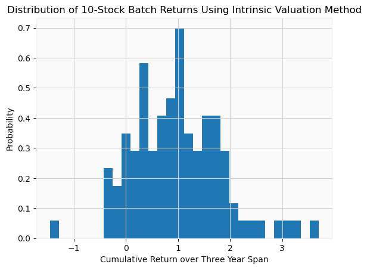

```python
def prices(symbol):
    calcval = []
    price = []
    for i in range(len(mrgval['Ticker Symbol'])):
        if mrgval['Ticker Symbol'][i] == symbol:
            calcval.append(mrgval['Share Value'][i])
            price.append(mrgval['Stock Price'][i])
    return(calcval,price)

def buy_sell(symbol):
    calcval,price = prices(symbol)
    profit = 0
    for i in range(len(calcval)-1):
        if calcval[i] < price[i]:
            profit+= (price[i+1]-price[i])/price[i]
    return(profit)


tickers = []
for i in mrgval['Ticker Symbol']:
    if i not in tickers:
        tickers.append(i)

def trials(n):
    tickerlist = []
    i = 0
    while i < n:
        tickerlist.append(random.choice(tickers))
        i+=1
    profit = 0
    for k in tickerlist:
        profit += buy_sell(k)
    return(profit)


total_trial_results = []
num = 0
while num < 100:
    total_trial_results.append(trials(10))
    num+=1

plt.hist(total_trial_results, density=True, bins=30)
plt.ylabel('Probability')
plt.xlabel('Cumulative Return over Three Year Span')
plt.title('Distribution of 10-Stock Batch Returns Using Intrinsic Valuation Method')
```

```python
meanreturn = sum(total_trial_results)/len(total_trial_results)
meanreturn
```

```
0.9783212575425074
```